# Effects of User Features on The Duration of Bike Rides

# By Ezemonye Ordu Omereji

## Investigation Overview

This part of the investigation focuses on the features of users that could impact on the duration of bike rides such as Age, Type, Gender and Status.

## Dataset Overview

The dataset comprises of comprises of 183,412 records of bike trips, with a total of 16 features (duration_sec, start_time, end_time, start_station_id,start_station_name, start_station_latitude,start_station_longitude, end_station_id, end_station_name, end_station_latitude, end_station_longitude, bike_id, user_type,member_birth_year, member_gender, bike_share_for_all_trip)

```
Index(['start_time', 'end_time', 'start_station_id', 'start_station_name',
       'end_station_id', 'end_station_name', 'bike_id', 'user_type',
       'member_birth_year', 'member_gender', 'bike_share_for_all_trip',
       'duration_minutes', 'start_hour', 'day_of_week', 'user_age'],
      dtype='object')
```

## User Age Distribution

The Age of users is an important feature which can have immense effect of how the system is used. Ages between 20 and 40 are observed to be more frequent with using the bike ride system.

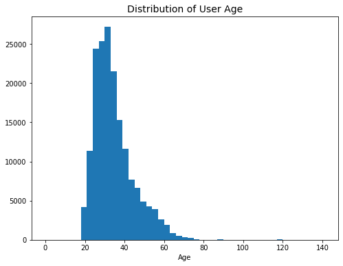

## User Type vs Daily Usage

The Subscriber type of users had much more trips than the Customers. This is in relation that the system had more Subscribers than Customers. THursdays had over 30,000 trips while weekend days were far less than half of it.

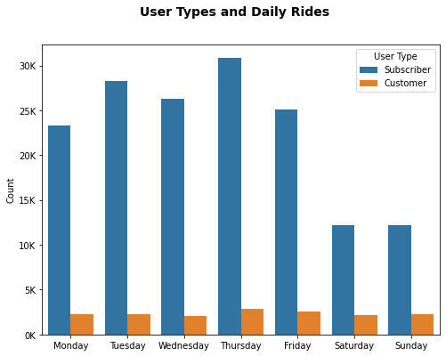

## User Age vs Ride Duration vs Gender

Maximum duration of trips were seen around users between 20 and 40 years of age. As age increases, users spend lesser time on bikes.

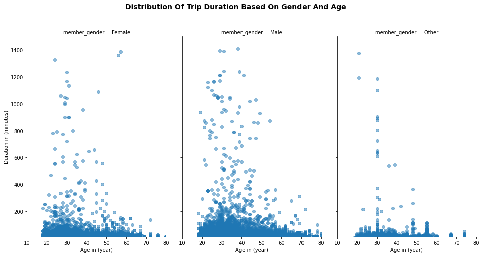